# Secondary Student Performance Prediction

Xiaoyun Zhuang (xiaoyun6), Yu Huang (yuh4), Junjing Liu (junjing2)

# Introduction

The quality of Portuguese secondary education is not so good as shown in the record of European Statistics [^1] in terms of the high failure rate. Statistical analysis is applied to the data to seek the potential of predicting students’ final grades based on their demographic information, social and school related features, and extracurricular attributes.

The first reason that we fit different statistical models to predict their final grades is that we would like to know whether the final exam is too hard or not. If the final exam is too hard, when we use the regular grading scale, many students will not get A. As a result, we need to curve their grades. If the model is good enough, when students’ actual grades differ a lot from their predicted grades, the instructor may need to curve the grades. So the model is used to give students a relatively fair final grade.

As for the second reason, we all know that sometimes, we do not do well on the final exam due to extraneous factors that are beyond our control even though we have worked very hard. Meanwhile, some students might do very well purely by luck even though they have not sufficiently learned the course materials. Neither situation is fair to all students. If we have a relatively good model to predict students’ final grades, and find that their actual grades are significantly better than their predicted grades, then it raises a warning signal and we may want to know the reasons. Besides, we may want to give them another chance, if students’ actual grades turn out to be substantially worse than the predicted grades.

# Method

## Data

The data originates from the UCI Machine Learning Respository [^2]. The data was collected from two public Portuguese schools using school reports and questionnaires during the 2005-2006 school year.

It contain two subsets respectively for Mathematics grades and Portuguese grades but here we only consider the data for Portuguese. It contains students’ 3-period grades for Portuguese language course, their demographic information , social-economic-status-related features, school-related attributes, and extracurricular predictors. The full data description could be found in Appendix.

Here is the first several rows of the data:

```r
data = read.csv("data/student-por.csv", sep = ";")
head(data)
```

```
##   school sex age address famsize Pstatus Medu Fedu     Mjob     Fjob
## 1     GP   F  18       U     GT3       A    4    4  at_home  teacher
## 2     GP   F  17       U     GT3       T    1    1  at_home    other
## 3     GP   F  15       U     LE3       T    1    1  at_home    other
## 4     GP   F  15       U     GT3       T    4    2   health services
## 5     GP   F  16       U     GT3       T    3    3    other    other
## 6     GP   M  16       U     LE3       T    4    3 services    other
##       reason guardian traveltime studytime failures schoolsup famsup paid
## 1     course   mother          2         2        0       yes     no   no
## 2     course   father          1         2        0        no    yes   no
## 3      other   mother          1         2        0       yes     no   no
## 4       home   mother          1         3        0        no    yes   no
## 5       home   father          1         2        0        no    yes   no
## 6 reputation   mother          1         2        0        no    yes   no
##   activities nursery higher internet romantic famrel freetime goout Dalc
## 1         no     yes    yes       no       no      4        3     4    1
## 2         no      no    yes      yes       no      5        3     3    1
## 3         no     yes    yes      yes       no      4        3     2    2
## 4        yes     yes    yes      yes      yes      3        2     2    1
## 5         no     yes    yes       no       no      4        3     2    1
## 6        yes     yes    yes      yes       no      5        4     2    1
##   Walc health absences G1 G2 G3
## 1    1      3        4  0 11 11
## 2    1      3        2  9 11 11
## 3    3      3        6 12 13 12
## 4    1      5        0 14 14 14
## 5    2      5        0 11 13 13
## 6    2      5        6 12 12 13
```

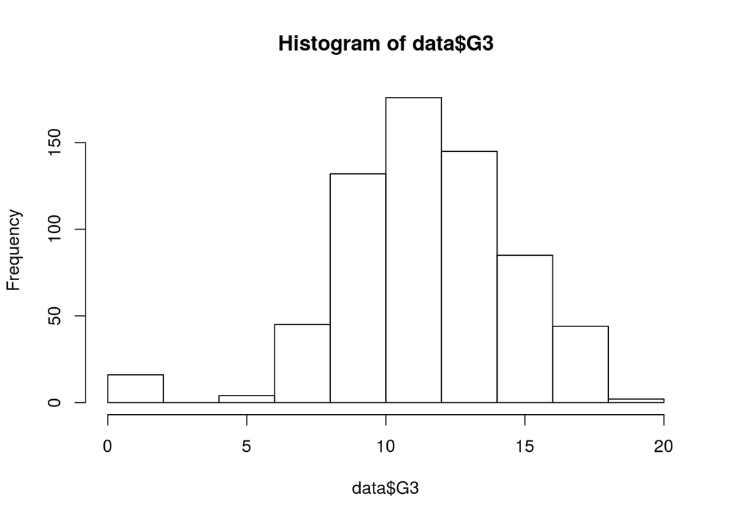

```r
hist(data$G3)
```

## Method

Here is the evidence to run the model.

```r
form = formula(G3 ~ . - G1 - G2)
lm_mod = lm(form, data = data[-c(1:5),])
summary(lm_mod)
```

```
##
## Call:
## lm(formula = form, data = data[-c(1:5), ])
##
## Residuals:
##      Min       1Q   Median       3Q      Max
## -12.7991  -1.3872   0.0026   1.5837   7.6095
##
## Coefficients:
##                   Estimate Std. Error t value Pr(>|t|)
## (Intercept)       8.585913   1.997070   4.299 2.00e-05 ***
## schoolMS         -1.214509   0.268437  -4.524 7.30e-06 ***
## sexM             -0.633638   0.251215  -2.522 0.011915 *
## age               0.167840   0.103084   1.628 0.104005
## addressU          0.331796   0.262686   1.263 0.207043
## famsizeLE3        0.284961   0.246484   1.156 0.248095
## PstatusT          0.141059   0.349663   0.403 0.686787
## Medu              0.041276   0.152365   0.271 0.786561
## Fedu              0.161834   0.138382   1.169 0.242674
## Mjobhealth        0.851949   0.542804   1.570 0.117047
## Mjobother         0.009485   0.306817   0.031 0.975348
## Mjobservices      0.379211   0.376913   1.006 0.314771
## Mjobteacher       0.463616   0.506591   0.915 0.360469
## Fjobhealth       -0.590118   0.754665  -0.782 0.434545
## Fjobother        -0.167205   0.457691  -0.365 0.714998
## Fjobservices     -0.631370   0.480820  -1.313 0.189644
## Fjobteacher       0.651567   0.679163   0.959 0.337758
## reasonhome        0.028028   0.287707   0.097 0.922427
## reasonother      -0.467810   0.370946  -1.261 0.207750
## reasonreputation  0.197850   0.299201   0.661 0.508696
## guardianmother   -0.367653   0.267647  -1.374 0.170060
## guardianother     0.059317   0.534200   0.111 0.911623
## traveltime        0.061028   0.159924   0.382 0.702889
## studytime         0.402913   0.140426   2.869 0.004259 **
## failures         -1.421600   0.205142  -6.930 1.08e-11 ***
## schoolsupyes     -1.302014   0.369781  -3.521 0.000462 ***
## famsupyes        -0.017151   0.229856  -0.075 0.940545
## paidyes          -0.369335   0.462804  -0.798 0.425162
## activitiesyes     0.207696   0.224441   0.925 0.355131
## nurseryyes       -0.239441   0.273042  -0.877 0.380868
## higheryes         1.746835   0.384003   4.549 6.52e-06 ***
## internetyes       0.242939   0.278716   0.872 0.383754
## romanticyes      -0.447577   0.230411  -1.943 0.052539 .
## famrel            0.167700   0.116590   1.438 0.150843
## freetime         -0.137365   0.112710  -1.219 0.223416
## goout            -0.059514   0.108035  -0.551 0.581920
## Dalc             -0.203898   0.153500  -1.328 0.184572
## Walc             -0.087719   0.118993  -0.737 0.461298
## health           -0.189268   0.077643  -2.438 0.015070 *
## absences         -0.038536   0.024964  -1.544 0.123191
## ---
## Signif. codes:  0 '***' 0.001 '**' 0.01 '*' 0.05 '.' 0.1 ' ' 1
##
## Residual standard error: 2.672 on 604 degrees of freedom
## Multiple R-squared:  0.3618, Adjusted R-squared:  0.3206
## F-statistic: 8.781 on 39 and 604 DF,  p-value: < 2.2e-16
```

```r
predict(lm_mod, data[1:5,])
```

```
##        1        2        3        4        5
## 13.17553 14.09881 11.04665 13.58055 13.39495
```

# Appendix

## Data Dictionary

- `sex`: student’s sex (binary: female or male)
- `age`: student’s age (numeric: from 15 to 22)
- `school`: student’s school (binary: **Gabriel Pereira** or **Mousinho da Silveira**)
- `address`: student’s home address type (binary: urban or rural)
- `Pstatus`: parent’s cohabitation status (binary: living together or apart)
- `Medu`: mother’s education (numeric: from 0 to 4[^3])
- `Mjob`: mother’s job (nominal[^4])
- `Fedu`: father’s education (numeric: from 0 to 4[^5])
- `Fjob`: father’s job (nominal[^6])
- `guardian`: student’s guardian (nominal: mother, father or other)
- `famsize`: family size (binary: ≤ 3 or > 3)
- `famrel`: quality of family relationships (numeric: from 1 – very bad to 5 – excellent)
- `reason`: reason to choose this school (nominal: close to home, school reputation, course preference or other)
- `traveltime`: home to school travel time (numeric: 1 – < 15 min., 2 – 15 to 30 min., 3 – 30 min. to 1 hour or 4 – > 1 hour)
- `studytime`: weekly study time (numeric: 1 – < 2 hours, 2 – 2 to 5 hours, 3 – 5 to 10 hours or 4 – > 10 hours)
- `failures`: number of past class failures (numeric: $n$ if 1 ≤ $n$ < 3, else 4)
- `schoolsup`: extra educational school support (binary: yes or no)
- `famsup`: family educational support (binary: yes or no)
- `activities`: extra-curricular activities (binary: yes or no)
- `paidclass`: extra paid classes (binary: yes or no)
- `internet`: Internet access at home (binary: yes or no)
- `nursery`: attended nursery school (binary: yes or no)
- `higher`: wants to take higher education (binary: yes or no)
- `romantic`: with a romantic relationship (binary: yes or no)
- `freetime`: free time after school (numeric: from 1 – very low to 5 – very high)
- `goout`: going out with friends (numeric: from 1 – very low to 5 – very high)
- `Walc`: weekend alcohol consumption (numeric: from 1 – very low to 5 – very high)
- `Dalc`: workday alcohol consumption (numeric: from 1 – very low to 5 – very high)
- `health`: current health status (numeric: from 1 – very bad to 5 – very good)
- `absences`: number of school absences (numeric: from 0 to 93)
- `G1`: first period grade (numeric: from 0 to 20)
- `G2`: second period grade (numeric: from 0 to 20)
- `G3`: final grade (numeric: from 0 to 20)